# Choosing the best model for House Price Prediction

Payel Nag

2024-07-31

## Introduction

Housing prices have shown significant fluctuations in growth rates across many countries recently. While housing prices generally trend upwards over time, accurately predicting these changes can be challenging. Various factors influence the demand for a property, and determining which factors are most influential in shaping buyer behavior is particularly difficult because individual buyers have unique preferences, such as the size of the house, location, and more. This project provides a comprehensive approach to house price prediction using regression techniques, demonstrating the process from data collection to model deployment. The dataset used for this analysis contains 545 observations and is sourced from [Kaggle](https://www.kaggle.com/datasets/harishkumardatalab/housing-price-prediction).

## Objective

The primary objective of this project is to predict house prices based on various features such as the number of bedrooms, number of bathrooms, area of the house,parking and other relevant attributes. This project aims to build a robust predictive model that can accurately estimate house prices, aiding stakeholders such as real estate agents, potential buyers, and sellers.

Data Collection: The dataset used in this project is sourced from the Kaggle House Prices dataset, which contains detailed information on various properties including their sale prices.

## Libraries

The following packages are used in this document viz.

- tidyverse(data manipulation),
- caret(creating predictive models),
- randomForest(classification and regression),
- xgboost(Boosting),
- gridExtra(Layout),
- corrplot(visualization) etc.

## Data Review

Lets load the data and review it throughly.

```
##      price area bedrooms bathrooms stories mainroad guestroom basement
## 1 13300000 7420        4         2       3      yes        no       no
## 2 12250000 8960        4         4       4      yes        no       no
## 3 12250000 9960        3         2       2      yes        no      yes
## 4 12215000 7500        4         2       2      yes        no      yes
## 5 11410000 7420        4         1       2      yes       yes      yes
## 6 10850000 7500        3         3       1      yes        no      yes
##   hotwaterheating airconditioning parking prefarea furnishingstatus
## 1              no             yes       2      yes        furnished
## 2              no             yes       3       no        furnished
## 3              no              no       2      yes   semi-furnished
## 4              no             yes       3      yes        furnished
## 5              no             yes       2       no        furnished
## 6              no             yes       2      yes   semi-furnished
```

The dataset contains 545 observations and 13 attributes.Below is a list of the variables with descriptions.

- Price: Price of each house sold.
- Area: Total area of the house.
- Bedrooms: The number of bedrooms in the house.
- Bathrooms: The number of bathrooms in the house.
- Stories: The number of stories in the house.
- Mainroad: Whether the house is connected to the main road (Yes/No).
- Guestroom: Whether the house has a guest room (Yes/No).
- Basement: Whether the house has a basement (Yes/No).
- Hotwaterheating: Whether the house has a hot water heating system (Yes/No).
- Airconditioning: Whether the house has an air conditioning system (Yes/No).
- Parking: The number of parking spaces available within the house.
- Prefarea: Whether the house is located in a preferred area (Yes/No).
- furnishingstatus: The furnishing status of the house (Fully Furnished, Semi-Furnished, Unfurnished).

## Missing or Duplicated Values

The first step is to check for and handle any missing values in the dataset.

```
##            price             area         bedrooms        bathrooms
##                0                0                0                0
##          stories         mainroad        guestroom         basement
##                0                0                0                0
##  hotwaterheating  airconditioning          parking         prefarea
##                0                0                0                0
## furnishingstatus
##                0
```

```
## [1] 0
```

```
## [1] 0
```

Fortunately, our dataset does not contain any missing values, which is beneficial for our analysis. In case there were missing values, we would need to make a decision on whether to impute the missing data or exclude the observations with missing values from the analysis.

## Data Processing

First we will see the structure and summary of the dataset.

```
##      price               area          bedrooms       bathrooms
##  Min.   : 1750000   Min.   : 1650   Min.   :1.000   Min.   :1.000
##  1st Qu.: 3430000   1st Qu.: 3600   1st Qu.:2.000   1st Qu.:1.000
##  Median : 4340000   Median : 4600   Median :3.000   Median :1.000
##  Mean   : 4766729   Mean   : 5151   Mean   :2.965   Mean   :1.286
##  3rd Qu.: 5740000   3rd Qu.: 6360   3rd Qu.:3.000   3rd Qu.:2.000
##  Max.   :13300000   Max.   :16200   Max.   :6.000   Max.   :4.000
##     stories        mainroad          guestroom           basement
##  Min.   :1.000   Length:545         Length:545         Length:545
##  1st Qu.:1.000   Class :character   Class :character   Class :character
##  Median :2.000   Mode  :character   Mode  :character   Mode  :character
##  Mean   :1.806
##  3rd Qu.:2.000
##  Max.   :4.000
##  hotwaterheating    airconditioning       parking         prefarea
##  Length:545         Length:545         Min.   :0.0000   Length:545
##  Class :character   Class :character   1st Qu.:0.0000   Class :character
##  Mode  :character   Mode  :character   Median :0.0000   Mode  :character
##                                        Mean   :0.6936
##                                        3rd Qu.:1.0000
##                                        Max.   :3.0000
##  furnishingstatus
##  Length:545
##  Class :character
##  Mode  :character
##
##
##
```

From the results above, it is evident that several variables have inappropriate data types. Therefore, we will rectify them as follows:

```
## 'data.frame':    545 obs. of  13 variables:
##  $ price           : int  13300000 12250000 12250000 12215000 11410000 10850000 10150000 10150000 9870000 9800000 ...
##  $ area            : int  7420 8960 9960 7500 7420 7500 8580 16200 8100 5750 ...
##  $ bedrooms        : int  4 4 3 4 4 3 4 5 4 3 ...
##  $ bathrooms       : int  2 4 2 2 1 3 3 3 1 2 ...
##  $ stories         : int  3 4 2 2 2 1 4 2 2 4 ...
##  $ mainroad        : Factor w/ 2 levels "no","yes": 2 2 2 2 2 2 2 2 2 2 ...
##  $ guestroom       : Factor w/ 2 levels "no","yes": 1 1 1 1 2 1 1 1 2 2 ...
##  $ basement        : Factor w/ 2 levels "no","yes": 1 1 2 2 2 2 1 1 2 1 ...
##  $ hotwaterheating : Factor w/ 2 levels "no","yes": 1 1 1 1 1 1 1 1 1 1 ...
##  $ airconditioning : Factor w/ 2 levels "no","yes": 2 2 1 2 2 2 2 1 2 2 ...
##  $ parking         : int  2 3 2 3 2 2 2 0 2 1 ...
##  $ prefarea        : Factor w/ 2 levels "no","yes": 2 1 2 2 1 2 2 1 2 2 ...
##  $ furnishingstatus: Factor w/ 3 levels "furnished","semi-furnished",..: 1 1 2 1 1 2 2 3 1 3 ...
```

## Exploratory Data Analysis

Exploratory data analysis (EDA) entails utilizing graphics and visualizations to thoroughly explore and analyze a dataset. The primary objective is to investigate and gain insights into the data variables present, facilitating a comprehensive understanding of the dataset’s characteristics.

## Data Distribution

Data distribution refers to the pattern or arrangement of data values in a dataset. It is a fundamental aspect of data analysis as it provides essential information about how the data is spread across different values. Understanding the distribution of data is crucial for making informed decisions, choosing appropriate statistical methods, and gaining insights into the underlying phenomena represented by the data.

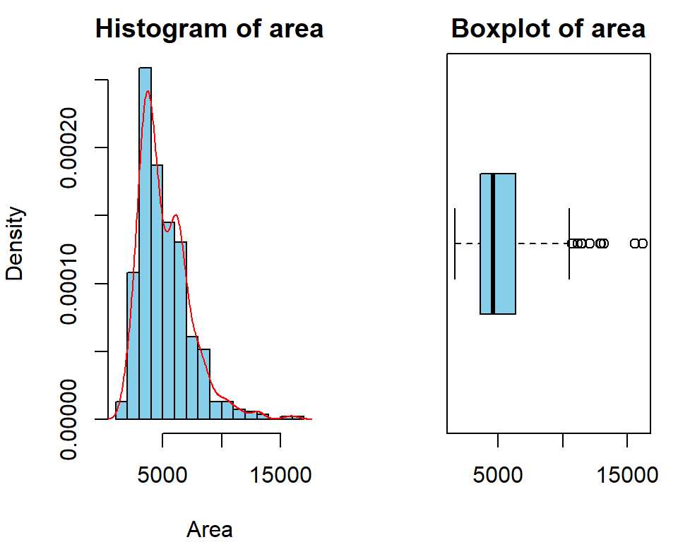

**Interpretation:** The histogram of the area attribute reflects a distribution with a central peak around the median value of 4,600, showing a concentration of house sizes between 3,600 and 6,360. The right skewness indicated by the mean being higher than the median will be visible as a gradual decrease in frequency towards the higher end of the distribution. This right-skewed pattern will be accentuated by the presence of a few extreme outliers with very large house sizes.

The boxplot illustrates a distribution where most house sizes are clustered between 3,600 and 6,360, with a median of 4,600. The mean being higher than the median suggests a right-skewed distribution with a tail extending towards larger values. The presence of an unusually high maximum value (16,200) indicates some extreme outliers in the dataset, which could be of particular interest for further investigation.

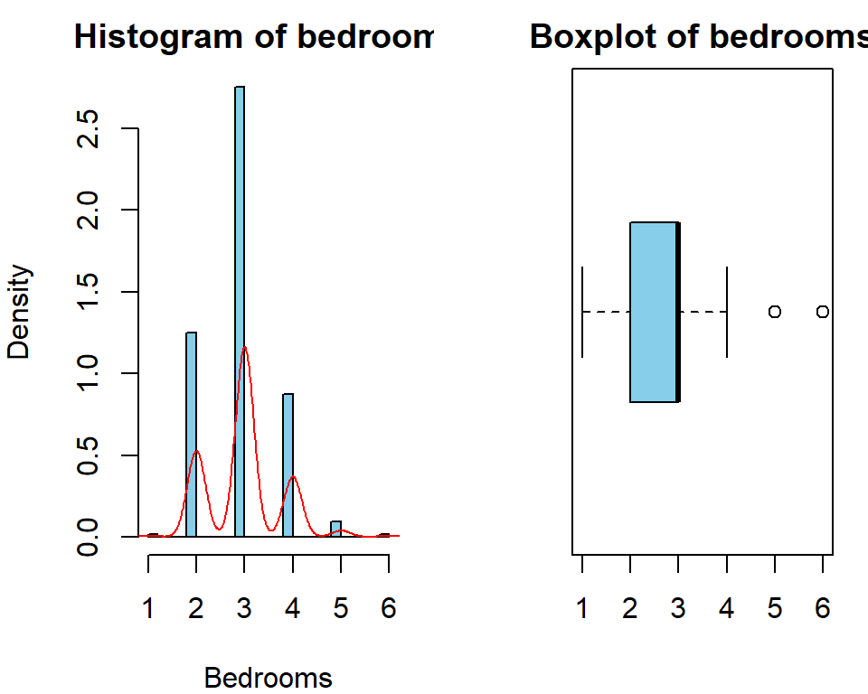

**Interpretation:**

The boxplot would illustrate that the majority of the data is concentrated around the median value of 3, with a relatively narrow interquartile range and a slight spread towards the maximum value. In complement, the histogram would visually depict this concentration around the central value of 3, while also revealing a distribution with some data points extending towards higher values, indicating a modest rightward skew.

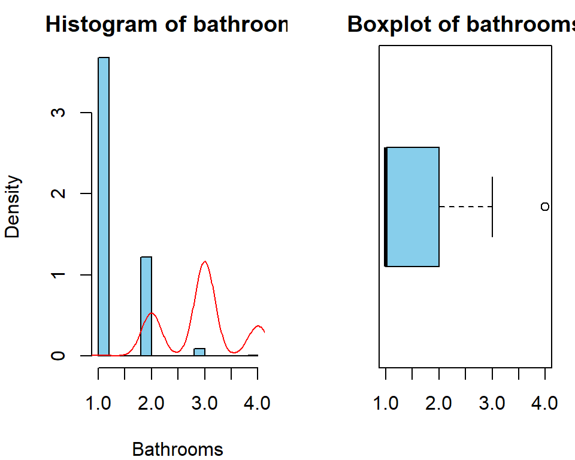

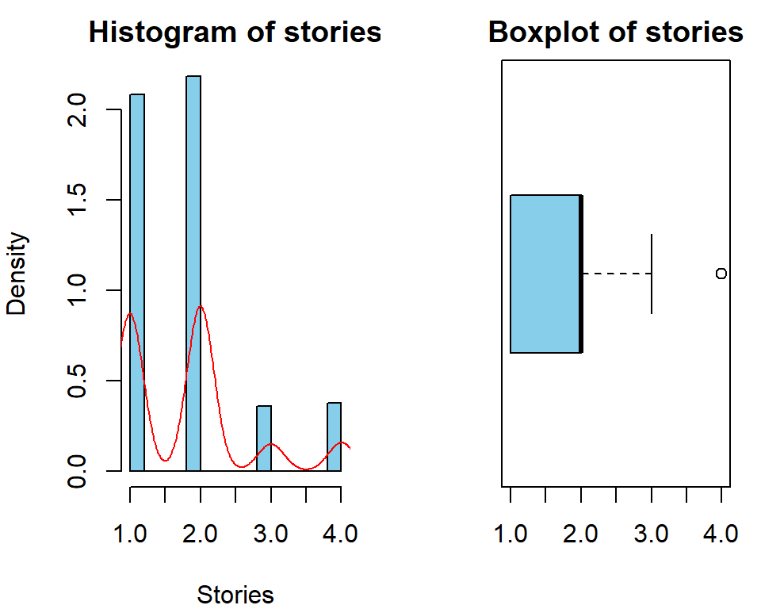

**Interpretation:**